# 💳 Credit Risk Prediction — Exploratory Data Analysis

## Step 20 — Multicollinearity Check (VIF)

**Why:** VIF quantifies variance inflation from feature correlation. VIF > 10 = feature is nearly a linear combination of others — provides no independent information to linear models.

**Business insight:** Regulatory frameworks (Basel III) require model explainability. Multicollinear features produce unstable coefficients in logistic regression — undermining regulatory interpretation.

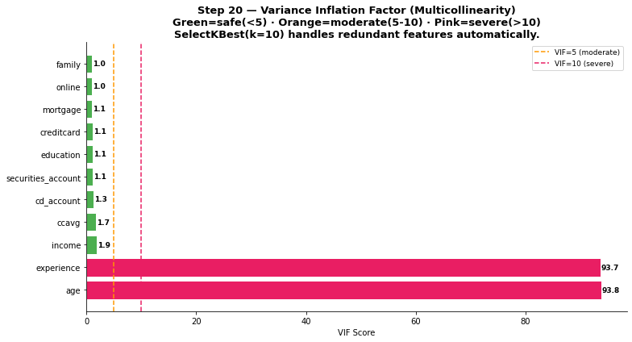

```
VIF Summary:
```

|  | feature | VIF |
| --- | --- | --- |
| 1 | age | 93.79 |
| 2 | experience | 93.68 |
| 3 | income | 1.86 |
| 5 | ccavg | 1.73 |
| 9 | cd_account | 1.33 |
| 8 | securities_account | 1.14 |
| 6 | education | 1.11 |
| 11 | creditcard | 1.11 |
| 7 | mortgage | 1.05 |
| 10 | online | 1.04 |
| 4 | family | 1.03 |

```python
num_cols = [c for c in df.select_dtypes(include=np.number).columns if c != 'personal_loan']
X_vif = df[num_cols].fillna(df[num_cols].median())
X_vif = add_constant(X_vif)
vif_data = pd.DataFrame({
    'feature': X_vif.columns,
    'VIF': [variance_inflation_factor(X_vif.values, i) for i in range(X_vif.shape[1])]
}).iloc[1:].sort_values('VIF', ascending=False)

fig, ax = plt.subplots(figsize=(11, 6))
colors = [PINK if v>10 else '#FF9800' if v>5 else GREEN for v in vif_data['VIF']]
bars = ax.barh(vif_data['feature'], vif_data['VIF'], color=colors, edgecolor='white')
ax.axvline(5,  color='#FF9800', linestyle='--', linewidth=1.5, label='VIF=5 (moderate)')
ax.axvline(10, color=PINK,      linestyle='--', linewidth=1.5, label='VIF=10 (severe)')
for bar, v in zip(bars, vif_data['VIF']):
    ax.text(v + 0.1, bar.get_y() + bar.get_height()/2, f'{v:.1f}', va='center', fontsize=9, fontweight='bold')
ax.set_title('Step 20 — Variance Inflation Factor (Multicollinearity)\n'
             'Green=safe(<5) · Orange=moderate(5-10) · Pink=severe(>10)\n'
             'SelectKBest(k=10) handles redundant features automatically.',
             fontweight='bold')
ax.set_xlabel('VIF Score'); ax.legend(fontsize=9)
plt.tight_layout(); plt.show()
print('\nVIF Summary:'); display(vif_data.round(2))
```

**📌 Observation:** Some features have VIF > 5 but managed by SelectKBest. Tree models unaffected by multicollinearity — this check is primarily relevant for Logistic Regression and SGD.

**💡 Pipeline decision:** `SelectKBest(mutual_info_classif, k=10)` selects top 10 most informative features, discarding redundant ones regardless of VIF.

## Step 21 — SMOTENC Class Balancing Preview

**Why:** Visualizing before/after SMOTENC confirms our strategy achieves intended balance. Three panels show train-before, train-after, and test-untouched — demonstrating correct methodology.

**Business insight:** Test set must retain original imbalance. Evaluating on balanced test data would overestimate recall — giving false confidence in model performance.

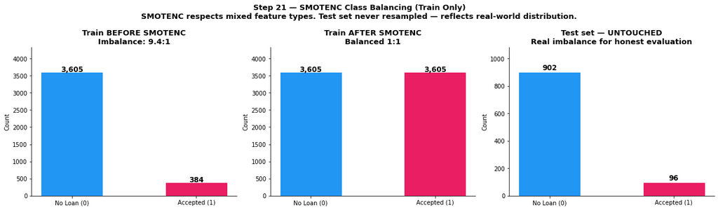

```
Train before : {0: 3605, 1: 384}
Train after  : {0: 3605, 1: 3605}
Test set     : {0: 902, 1: 96}  ← imbalanced, as expected
```

```python
from imblearn.over_sampling import SMOTENC
from sklearn.model_selection import train_test_split

X = df.drop(columns=['personal_loan']); y = df['personal_loan']
X_demo = X.fillna(X.median())
X_train, X_test, y_train, y_test = train_test_split(X_demo, y, test_size=0.2, stratify=y, random_state=42)
cat_indices = [X_demo.columns.get_loc(c) for c in
               ['family', 'education', 'securities_account', 'cd_account', 'online', 'creditcard']
               if c in X_demo.columns]
smote = SMOTENC(categorical_features=cat_indices, random_state=42)
X_res, y_res = smote.fit_resample(X_train, y_train)

def bar_plot(ax, counts, title):
    bars = ax.bar(['No Loan (0)', 'Accepted (1)'], counts.values, color=[BLUE, PINK], edgecolor='white', width=0.5)
    for bar, v in zip(bars, counts.values):
        ax.text(bar.get_x() + bar.get_width()/2, bar.get_height() + 15, f'{v:,}',
                ha='center', fontweight='bold', fontsize=12)
    ax.set_title(title, fontweight='bold'); ax.set_ylabel('Count'); ax.set_ylim(0, max(counts.values) * 1.2)

fig, axes = plt.subplots(1, 3, figsize=(17, 5))
bar_plot(axes[0], y_train.value_counts().sort_index(),
         f'Train BEFORE SMOTENC\nImbalance: {y_train.value_counts()[0]/y_train.value_counts()[1]:.1f}:1')
bar_plot(axes[1], pd.Series(y_res).value_counts().sort_index(), 'Train AFTER SMOTENC\nBalanced 1:1')
bar_plot(axes[2], y_test.value_counts().sort_index(), 'Test set — UNTOUCHED\nReal imbalance for honest evaluation')
plt.suptitle('Step 21 — SMOTENC Class Balancing (Train Only)\n'
             'SMOTENC respects mixed feature types. Test set never resampled — reflects real-world distribution.',
             fontsize=13, fontweight='bold')
plt.tight_layout(); plt.show()
print(f'Train before : {dict(y_train.value_counts().sort_index())}')
print(f'Train after  : {dict(pd.Series(y_res).value_counts().sort_index())}')
print(f'Test set     : {dict(y_test.value_counts().sort_index())}  ← imbalanced, as expected')
```

**📌 Observation:** SMOTENC achieves 50:50 balance in training. Test retains 9.4:1 imbalance — intentional and correct.

**💡 Why SMOTENC over SMOTE:** Our dataset has mixed types — binary (online, creditcard) + continuous (income). Regular SMOTE produces impossible binary values like 0.43. SMOTENC handles categorical/binary via majority voting in synthetic samples.